# Google Data Analytics Capstone Project: Cyclistic Bike - Share Analysis Case Study

Aminuddin Hilmi Ahmad

10/10/2021

### About the company

In 2016, Cyclistic launched a successful bike-share offering. Since then, the program has grown to a fleet of 5,824 bicycles that are geotracked and locked into a network of 692 stations across Chicago. The bikes can be unlocked from one station and returned to any other station in the system anytime.

Until now, Cyclistic’s marketing strategy relied on building general awareness and appealing to broad consumer segments. One approach that helped make these things possible was the flexibility of its pricing plans: single-ride passes, full-day passes, and annual memberships. Customers who purchase single-ride or full-day passes are referred to as casual riders. Customers who purchase annual memberships are Cyclistic members.

### Ask - The Business Task & Objective

Cyclistic’s finance analysts have concluded that annual members are much more profitable than casual riders. Although the pricing flexibility helps Cyclistic attract more customers, Lily Moreno, the marketing director, believes that maximizing the number of annual members will be key to future growth. Rather than creating a marketing campaign that targets all-new customers, Moreno believes there is a very good chance to convert casual riders into members. She notes that casual riders are already aware of the Cyclistic program and have chosen Cyclistic for their mobility needs.

Moreno has set a clear goal: Design marketing strategies aimed at converting casual riders into annual members. In order to do that, however, the marketing analyst team needs to better understand how annual members and casual riders differ, why casual riders would buy a membership, and how digital media could affect their marketing tactics. Moreno and her team are interested in analysing the Cyclistic historical bike trip data to identify trends.

The main objective, identifying how do annual members and casual riders use Cyclistic bikes differently?

### Prepare - The Dataset

The past data trip was obtained from [here](https://divvy-tripdata.s3.amazonaws.com/index.html). Its a public data set prepared by the Motivate International Inc (“Motivate”), the bike - sharing company operated in Chicago, Illinois, USA. Since its a first party data sets, the data is considered as fulfilling the ROCCC requirement ie. the data is reliable, original, comprehensive, current, and cited.

The data set chosen were from January 2020 to December 2020. The 12 months data will give a better accuracy analysis in identifying the pattern of usage between the casual and member user.

### Process - Cleaning The Data

The datasets were processed in RStudio. R was chosen due to its ability in processing the millions rows of data faster and its powerful ‘Tidyverse’ package that simplify a lot of data cleaning process. R also have ‘ggplot2’ package that can easily visualise the data in graphical form that help to comprehend the data faster and efficiently.

The breakdown of the process are as follow;

```r
#################################################

#Running the packages

library(tidyverse)
library(here)
library(skimr)
library(janitor)
library(lubridate)
library(hms)
#################################################

#Importing datasets

Q01_2020 <- read_csv("Divvy_Trips_2020_Q1.csv")
M04_2020 <- read_csv("202004-divvy-tripdata.csv")
M05_2020 <- read_csv("202005-divvy-tripdata.csv")
M06_2020 <- read_csv("202006-divvy-tripdata.csv")
M07_2020 <- read_csv("202007-divvy-tripdata.csv")
M08_2020 <- read_csv("202008-divvy-tripdata.csv")
M09_2020 <- read_csv("202009-divvy-tripdata.csv")
M10_2020 <- read_csv("202010-divvy-tripdata.csv")
M11_2020 <- read_csv("202011-divvy-tripdata.csv")
M12_2020 <- read_csv("202012-divvy-tripdata.csv")
#Inspecting the datasets

str(Q01_2020)
```

```
## spec_tbl_df [426,887 × 13] (S3: spec_tbl_df/tbl_df/tbl/data.frame)
##  $ ride_id           : chr [1:426887] "EACB19130B0CDA4A" "8FED874C809DC021" "789F3C21E472CA96" "C9A388DAC6ABF313" ...
##  $ rideable_type     : chr [1:426887] "docked_bike" "docked_bike" "docked_bike" "docked_bike" ...
##  $ started_at        : POSIXct[1:426887], format: "2020-01-21 20:06:59" "2020-01-30 14:22:39" ...
##  $ ended_at          : POSIXct[1:426887], format: "2020-01-21 20:14:30" "2020-01-30 14:26:22" ...
##  $ start_station_name: chr [1:426887] "Western Ave & Leland Ave" "Clark St & Montrose Ave" "Broadway & Belmont Ave" "Clark St & Randolph St" ...
##  $ start_station_id  : num [1:426887] 239 234 296 51 66 212 96 96 212 38 ...
##  $ end_station_name  : chr [1:426887] "Clark St & Leland Ave" "Southport Ave & Irving Park Rd" "Wilton Ave & Belmont Ave" "Fairbanks Ct & Grand Ave" ...
##  $ end_station_id    : num [1:426887] 326 318 117 24 212 96 212 212 96 100 ...
##  $ start_lat         : num [1:426887] 42 42 41.9 41.9 41.9 ...
##  $ start_lng         : num [1:426887] -87.7 -87.7 -87.6 -87.6 -87.6 ...
##  $ end_lat           : num [1:426887] 42 42 41.9 41.9 41.9 ...
##  $ end_lng           : num [1:426887] -87.7 -87.7 -87.7 -87.6 -87.6 ...
##  $ member_casual     : chr [1:426887] "member" "member" "member" "member" ...
##  - attr(*, "spec")=
##   .. cols(
##   ..   ride_id = col_character(),
##   ..   rideable_type = col_character(),
##   ..   started_at = col_datetime(format = ""),
##   ..   ended_at = col_datetime(format = ""),
##   ..   start_station_name = col_character(),
##   ..   start_station_id = col_double(),
##   ..   end_station_name = col_character(),
##   ..   end_station_id = col_double(),
##   ..   start_lat = col_double(),
##   ..   start_lng = col_double(),
##   ..   end_lat = col_double(),
##   ..   end_lng = col_double(),
##   ..   member_casual = col_character()
##   .. )
##  - attr(*, "problems")=<externalptr>
```

```r
str(M04_2020)
```

```
## spec_tbl_df [84,776 × 13] (S3: spec_tbl_df/tbl_df/tbl/data.frame)
##  $ ride_id           : chr [1:84776] "A847FADBBC638E45" "5405B80E996FF60D" "5DD24A79A4E006F4" "2A59BBDF5CDBA725" ...
##  $ rideable_type     : chr [1:84776] "docked_bike" "docked_bike" "docked_bike" "docked_bike" ...
##  $ started_at        : POSIXct[1:84776], format: "2020-04-26 17:45:14" "2020-04-17 17:08:54" ...
##  $ ended_at          : POSIXct[1:84776], format: "2020-04-26 18:12:03" "2020-04-17 17:17:03" ...
##  $ start_station_name: chr [1:84776] "Eckhart Park" "Drake Ave & Fullerton Ave" "McClurg Ct & Erie St" "California Ave & Division St" ...
##  $ start_station_id  : num [1:84776] 86 503 142 216 125 173 35 434 627 377 ...
##  $ end_station_name  : chr [1:84776] "Lincoln Ave & Diversey Pkwy" "Kosciuszko Park" "Indiana Ave & Roosevelt Rd" "Wood St & Augusta Blvd" ...
##  $ end_station_id    : num [1:84776] 152 499 255 657 323 35 635 382 359 508 ...
##  $ start_lat         : num [1:84776] 41.9 41.9 41.9 41.9 41.9 ...
##  $ start_lng         : num [1:84776] -87.7 -87.7 -87.6 -87.7 -87.6 ...
##  $ end_lat           : num [1:84776] 41.9 41.9 41.9 41.9 42 ...
##  $ end_lng           : num [1:84776] -87.7 -87.7 -87.6 -87.7 -87.7 ...
##  $ member_casual     : chr [1:84776] "member" "member" "member" "member" ...
##  - attr(*, "spec")=
##   .. cols(
##   ..   ride_id = col_character(),
##   ..   rideable_type = col_character(),
##   ..   started_at = col_datetime(format = ""),
##   ..   ended_at = col_datetime(format = ""),
##   ..   start_station_name = col_character(),
##   ..   start_station_id = col_double(),
##   ..   end_station_name = col_character(),
##   ..   end_station_id = col_double(),
##   ..   start_lat = col_double(),
##   ..   start_lng = col_double(),
##   ..   end_lat = col_double(),
##   ..   end_lng = col_double(),
##   ..   member_casual = col_character()
##   .. )
##  - attr(*, "problems")=<externalptr>
```

```r
str(M05_2020)
```

```
## spec_tbl_df [200,274 × 13] (S3: spec_tbl_df/tbl_df/tbl/data.frame)
##  $ ride_id           : chr [1:200274] "02668AD35674B983" "7A50CCAF1EDDB28F" "2FFCDFDB91FE9A52" "58991CF1DB75BA84" ...
##  $ rideable_type     : chr [1:200274] "docked_bike" "docked_bike" "docked_bike" "docked_bike" ...
##  $ started_at        : POSIXct[1:200274], format: "2020-05-27 10:03:52" "2020-05-25 10:47:11" ...
##  $ ended_at          : POSIXct[1:200274], format: "2020-05-27 10:16:49" "2020-05-25 11:05:40" ...
##  $ start_station_name: chr [1:200274] "Franklin St & Jackson Blvd" "Clark St & Wrightwood Ave" "Kedzie Ave & Milwaukee Ave" "Clarendon Ave & Leland Ave" ...
##  $ start_station_id  : num [1:200274] 36 340 260 251 261 206 261 180 331 219 ...
##  $ end_station_name  : chr [1:200274] "Wabash Ave & Grand Ave" "Clark St & Leland Ave" "Kedzie Ave & Milwaukee Ave" "Lake Shore Dr & Wellington Ave" ...
##  $ end_station_id    : num [1:200274] 199 326 260 157 206 22 261 180 300 305 ...
##  $ start_lat         : num [1:200274] 41.9 41.9 41.9 42 41.9 ...
##  $ start_lng         : num [1:200274] -87.6 -87.6 -87.7 -87.7 -87.7 ...
##  $ end_lat           : num [1:200274] 41.9 42 41.9 41.9 41.8 ...
##  $ end_lng           : num [1:200274] -87.6 -87.7 -87.7 -87.6 -87.6 ...
##  $ member_casual     : chr [1:200274] "member" "casual" "casual" "casual" ...
##  - attr(*, "spec")=
##   .. cols(
##   ..   ride_id = col_character(),
##   ..   rideable_type = col_character(),
##   ..   started_at = col_datetime(format = ""),
##   ..   ended_at = col_datetime(format = ""),
##   ..   start_station_name = col_character(),
##   ..   start_station_id = col_double(),
##   ..   end_station_name = col_character(),
##   ..   end_station_id = col_double(),
##   ..   start_lat = col_double(),
##   ..   start_lng = col_double(),
##   ..   end_lat = col_double(),
##   ..   end_lng = col_double(),
##   ..   member_casual = col_character()
##   .. )
##  - attr(*, "problems")=<externalptr>
```

```r
str(M06_2020)
```

```
## spec_tbl_df [343,005 × 13] (S3: spec_tbl_df/tbl_df/tbl/data.frame)
##  $ ride_id           : chr [1:343005] "8CD5DE2C2B6C4CFC" "9A191EB2C751D85D" "F37D14B0B5659BCF" "C41237B506E85FA1" ...
##  $ rideable_type     : chr [1:343005] "docked_bike" "docked_bike" "docked_bike" "docked_bike" ...
##  $ started_at        : POSIXct[1:343005], format: "2020-06-13 23:24:48" "2020-06-26 07:26:10" ...
##  $ ended_at          : POSIXct[1:343005], format: "2020-06-13 23:36:55" "2020-06-26 07:31:58" ...
##  $ start_station_name: chr [1:343005] "Wilton Ave & Belmont Ave" "Federal St & Polk St" "Daley Center Plaza" "Broadway & Cornelia Ave" ...
##  $ start_station_id  : num [1:343005] 117 41 81 303 327 327 41 115 338 84 ...
##  $ end_station_name  : chr [1:343005] "Damen Ave & Clybourn Ave" "Daley Center Plaza" "State St & Harrison St" "Broadway & Berwyn Ave" ...
##  $ end_station_id    : num [1:343005] 163 81 5 294 117 117 81 303 164 53 ...
##  $ start_lat         : num [1:343005] 41.9 41.9 41.9 41.9 41.9 ...
##  $ start_lng         : num [1:343005] -87.7 -87.6 -87.6 -87.6 -87.7 ...
##  $ end_lat           : num [1:343005] 41.9 41.9 41.9 42 41.9 ...
##  $ end_lng           : num [1:343005] -87.7 -87.6 -87.6 -87.7 -87.7 ...
##  $ member_casual     : chr [1:343005] "casual" "member" "member" "casual" ...
##  - attr(*, "spec")=
##   .. cols(
##   ..   ride_id = col_character(),
##   ..   rideable_type = col_character(),
##   ..   started_at = col_datetime(format = ""),
##   ..   ended_at = col_datetime(format = ""),
##   ..   start_station_name = col_character(),
##   ..   start_station_id = col_double(),
##   ..   end_station_name = col_character(),
##   ..   end_station_id = col_double(),
##   ..   start_lat = col_double(),
##   ..   start_lng = col_double(),
##   ..   end_lat = col_double(),
##   ..   end_lng = col_double(),
##   ..   member_casual = col_character()
##   .. )
##  - attr(*, "problems")=<externalptr>
```

```r
str(M07_2020)
```

```
## spec_tbl_df [551,480 × 13] (S3: spec_tbl_df/tbl_df/tbl/data.frame)
##  $ ride_id           : chr [1:551480] "762198876D69004D" "BEC9C9FBA0D4CF1B" "D2FD8EA432C77EC1" "54AE594E20B35881" ...
##  $ rideable_type     : chr [1:551480] "docked_bike" "docked_bike" "docked_bike" "docked_bike" ...
##  $ started_at        : POSIXct[1:551480], format: "2020-07-09 15:22:02" "2020-07-24 23:56:30" ...
##  $ ended_at          : POSIXct[1:551480], format: "2020-07-09 15:25:52" "2020-07-25 00:20:17" ...
##  $ start_station_name: chr [1:551480] "Ritchie Ct & Banks St" "Halsted St & Roscoe St" "Lake Shore Dr & Diversey Pkwy" "LaSalle St & Illinois St" ...
##  $ start_station_id  : num [1:551480] 180 299 329 181 268 635 113 211 176 31 ...
##  $ end_station_name  : chr [1:551480] "Wells St & Evergreen Ave" "Broadway & Ridge Ave" "Clark St & Wellington Ave" "Clark St & Armitage Ave" ...
##  $ end_station_id    : num [1:551480] 291 461 156 94 301 289 140 31 191 142 ...
##  $ start_lat         : num [1:551480] 41.9 41.9 41.9 41.9 41.9 ...
##  $ start_lng         : num [1:551480] -87.6 -87.6 -87.6 -87.6 -87.6 ...
##  $ end_lat           : num [1:551480] 41.9 42 41.9 41.9 41.9 ...
##  $ end_lng           : num [1:551480] -87.6 -87.7 -87.6 -87.6 -87.6 ...
##  $ member_casual     : chr [1:551480] "member" "member" "casual" "casual" ...
##  - attr(*, "spec")=
##   .. cols(
##   ..   ride_id = col_character(),
##   ..   rideable_type = col_character(),
##   ..   started_at = col_datetime(format = ""),
##   ..   ended_at = col_datetime(format = ""),
##   ..   start_station_name = col_character(),
##   ..   start_station_id = col_double(),
##   ..   end_station_name = col_character(),
##   ..   end_station_id = col_double(),
##   ..   start_lat = col_double(),
##   ..   start_lng = col_double(),
##   ..   end_lat = col_double(),
##   ..   end_lng = col_double(),
##   ..   member_casual = col_character()
##   .. )
##  - attr(*, "problems")=<externalptr>
```

```r
str(M08_2020)
```

```
## spec_tbl_df [622,361 × 13] (S3: spec_tbl_df/tbl_df/tbl/data.frame)
##  $ ride_id           : chr [1:622361] "322BD23D287743ED" "2A3AEF1AB9054D8B" "67DC1D133E8B5816" "C79FBBD412E578A7" ...
##  $ rideable_type     : chr [1:622361] "docked_bike" "electric_bike" "electric_bike" "electric_bike" ...
##  $ started_at        : POSIXct[1:622361], format: "2020-08-20 18:08:14" "2020-08-27 18:46:04" ...
##  $ ended_at          : POSIXct[1:622361], format: "2020-08-20 18:17:51" "2020-08-27 19:54:51" ...
##  $ start_station_name: chr [1:622361] "Lake Shore Dr & Diversey Pkwy" "Michigan Ave & 14th St" "Columbus Dr & Randolph St" "Daley Center Plaza" ...
##  $ start_station_id  : num [1:622361] 329 168 195 81 658 658 196 67 153 177 ...
##  $ end_station_name  : chr [1:622361] "Clark St & Lincoln Ave" "Michigan Ave & 14th St" "State St & Randolph St" "State St & Kinzie St" ...
##  $ end_station_id    : num [1:622361] 141 168 44 47 658 658 49 229 225 305 ...
##  $ start_lat         : num [1:622361] 41.9 41.9 41.9 41.9 41.9 ...
##  $ start_lng         : num [1:622361] -87.6 -87.6 -87.6 -87.6 -87.7 ...
##  $ end_lat           : num [1:622361] 41.9 41.9 41.9 41.9 41.9 ...
##  $ end_lng           : num [1:622361] -87.6 -87.6 -87.6 -87.6 -87.7 ...
##  $ member_casual     : chr [1:622361] "member" "casual" "casual" "casual" ...
##  - attr(*, "spec")=
##   .. cols(
##   ..   ride_id = col_character(),
##   ..   rideable_type = col_character(),
##   ..   started_at = col_datetime(format = ""),
##   ..   ended_at = col_datetime(format = ""),
##   ..   start_station_name = col_character(),
##   ..   start_station_id = col_double(),
##   ..   end_station_name = col_character(),
##   ..   end_station_id = col_double(),
##   ..   start_lat = col_double(),
##   ..   start_lng = col_double(),
##   ..   end_lat = col_double(),
##   ..   end_lng = col_double(),
##   ..   member_casual = col_character()
##   .. )
##  - attr(*, "problems")=<externalptr>
```

```r
str(M09_2020)
```

```
## spec_tbl_df [532,958 × 13] (S3: spec_tbl_df/tbl_df/tbl/data.frame)
##  $ ride_id           : chr [1:532958] "2B22BD5F95FB2629" "A7FB70B4AFC6CAF2" "86057FA01BAC778E" "57F6DC9A153DB98C" ...
##  $ rideable_type     : chr [1:532958] "electric_bike" "electric_bike" "electric_bike" "electric_bike" ...
##  $ started_at        : POSIXct[1:532958], format: "2020-09-17 14:27:11" "2020-09-17 15:07:31" ...
##  $ ended_at          : POSIXct[1:532958], format: "2020-09-17 14:44:24" "2020-09-17 15:07:45" ...
##  $ start_station_name: chr [1:532958] "Michigan Ave & Lake St" "W Oakdale Ave & N Broadway" "W Oakdale Ave & N Broadway" "Ashland Ave & Belle Plaine Ave" ...
##  $ start_station_id  : num [1:532958] 52 NA NA 246 24 94 291 NA NA NA ...
##  $ end_station_name  : chr [1:532958] "Green St & Randolph St" "W Oakdale Ave & N Broadway" "W Oakdale Ave & N Broadway" "Montrose Harbor" ...
##  $ end_station_id    : num [1:532958] 112 NA NA 249 24 NA 256 NA NA NA ...
##  $ start_lat         : num [1:532958] 41.9 41.9 41.9 42 41.9 ...
##  $ start_lng         : num [1:532958] -87.6 -87.6 -87.6 -87.7 -87.6 ...
##  $ end_lat           : num [1:532958] 41.9 41.9 41.9 42 41.9 ...
##  $ end_lng           : num [1:532958] -87.6 -87.6 -87.6 -87.6 -87.6 ...
##  $ member_casual     : chr [1:532958] "casual" "casual" "casual" "casual" ...
##  - attr(*, "spec")=
##   .. cols(
##   ..   ride_id = col_character(),
##   ..   rideable_type = col_character(),
##   ..   started_at = col_datetime(format = ""),
##   ..   ended_at = col_datetime(format = ""),
##   ..   start_station_name = col_character(),
##   ..   start_station_id = col_double(),
##   ..   end_station_name = col_character(),
##   ..   end_station_id = col_double(),
##   ..   start_lat = col_double(),
##   ..   start_lng = col_double(),
##   ..   end_lat = col_double(),
##   ..   end_lng = col_double(),
##   ..   member_casual = col_character()
##   .. )
##  - attr(*, "problems")=<externalptr>
```

```r
str(M10_2020)
```

```
## spec_tbl_df [388,653 × 13] (S3: spec_tbl_df/tbl_df/tbl/data.frame)
##  $ ride_id           : chr [1:388653] "ACB6B40CF5B9044C" "DF450C72FD109C01" "B6396B54A15AC0DF" "44A4AEE261B9E854" ...
##  $ rideable_type     : chr [1:388653] "electric_bike" "electric_bike" "electric_bike" "electric_bike" ...
##  $ started_at        : POSIXct[1:388653], format: "2020-10-31 19:39:43" "2020-10-31 23:50:08" ...
##  $ ended_at          : POSIXct[1:388653], format: "2020-10-31 19:57:12" "2020-11-01 00:04:16" ...
##  $ start_station_name: chr [1:388653] "Lakeview Ave & Fullerton Pkwy" "Southport Ave & Waveland Ave" "Stony Island Ave & 67th St" "Clark St & Grace St" ...
##  $ start_station_id  : num [1:388653] 313 227 102 165 190 359 313 125 NA 174 ...
##  $ end_station_name  : chr [1:388653] "Rush St & Hubbard St" "Kedzie Ave & Milwaukee Ave" "University Ave & 57th St" "Broadway & Sheridan Rd" ...
##  $ end_station_id    : num [1:388653] 125 260 423 256 185 53 125 313 199 635 ...
##  $ start_lat         : num [1:388653] 41.9 41.9 41.8 42 41.9 ...
##  $ start_lng         : num [1:388653] -87.6 -87.7 -87.6 -87.7 -87.7 ...
##  $ end_lat           : num [1:388653] 41.9 41.9 41.8 42 41.9 ...
##  $ end_lng           : num [1:388653] -87.6 -87.7 -87.6 -87.7 -87.7 ...
##  $ member_casual     : chr [1:388653] "casual" "casual" "casual" "casual" ...
##  - attr(*, "spec")=
##   .. cols(
##   ..   ride_id = col_character(),
##   ..   rideable_type = col_character(),
##   ..   started_at = col_datetime(format = ""),
##   ..   ended_at = col_datetime(format = ""),
##   ..   start_station_name = col_character(),
##   ..   start_station_id = col_double(),
##   ..   end_station_name = col_character(),
##   ..   end_station_id = col_double(),
##   ..   start_lat = col_double(),
##   ..   start_lng = col_double(),
##   ..   end_lat = col_double(),
##   ..   end_lng = col_double(),
##   ..   member_casual = col_character()
##   .. )
##  - attr(*, "problems")=<externalptr>
```

```r
str(M11_2020)
```

```
## spec_tbl_df [259,716 × 13] (S3: spec_tbl_df/tbl_df/tbl/data.frame)
##  $ ride_id           : chr [1:259716] "BD0A6FF6FFF9B921" "96A7A7A4BDE4F82D" "C61526D06582BDC5" "E533E89C32080B9E" ...
##  $ rideable_type     : chr [1:259716] "electric_bike" "electric_bike" "electric_bike" "electric_bike" ...
##  $ started_at        : POSIXct[1:259716], format: "2020-11-01 13:36:00" "2020-11-01 10:03:26" ...
##  $ ended_at          : POSIXct[1:259716], format: "2020-11-01 13:45:40" "2020-11-01 10:14:45" ...
##  $ start_station_name: chr [1:259716] "Dearborn St & Erie St" "Franklin St & Illinois St" "Lake Shore Dr & Monroe St" "Leavitt St & Chicago Ave" ...
##  $ start_station_id  : num [1:259716] 110 672 76 659 2 72 76 NA 58 394 ...
##  $ end_station_name  : chr [1:259716] "St. Clair St & Erie St" "Noble St & Milwaukee Ave" "Federal St & Polk St" "Stave St & Armitage Ave" ...
##  $ end_station_id    : num [1:259716] 211 29 41 185 2 76 72 NA 288 273 ...
##  $ start_lat         : num [1:259716] 41.9 41.9 41.9 41.9 41.9 ...
##  $ start_lng         : num [1:259716] -87.6 -87.6 -87.6 -87.7 -87.6 ...
##  $ end_lat           : num [1:259716] 41.9 41.9 41.9 41.9 41.9 ...
##  $ end_lng           : num [1:259716] -87.6 -87.7 -87.6 -87.7 -87.6 ...
##  $ member_casual     : chr [1:259716] "casual" "casual" "casual" "casual" ...
##  - attr(*, "spec")=
##   .. cols(
##   ..   ride_id = col_character(),
##   ..   rideable_type = col_character(),
##   ..   started_at = col_datetime(format = ""),
##   ..   ended_at = col_datetime(format = ""),
##   ..   start_station_name = col_character(),
##   ..   start_station_id = col_double(),
##   ..   end_station_name = col_character(),
##   ..   end_station_id = col_double(),
##   ..   start_lat = col_double(),
##   ..   start_lng = col_double(),
##   ..   end_lat = col_double(),
##   ..   end_lng = col_double(),
##   ..   member_casual = col_character()
##   .. )
##  - attr(*, "problems")=<externalptr>
```

```r
str(M12_2020)
```

```
## spec_tbl_df [131,573 × 13] (S3: spec_tbl_df/tbl_df/tbl/data.frame)
##  $ ride_id           : chr [1:131573] "70B6A9A437D4C30D" "158A465D4E74C54A" "5262016E0F1F2F9A" "BE119628E44F871E" ...
##  $ rideable_type     : chr [1:131573] "classic_bike" "electric_bike" "electric_bike" "electric_bike" ...
##  $ started_at        : POSIXct[1:131573], format: "2020-12-27 12:44:29" "2020-12-18 17:37:15" ...
##  $ ended_at          : POSIXct[1:131573], format: "2020-12-27 12:55:06" "2020-12-18 17:44:19" ...
##  $ start_station_name: chr [1:131573] "Aberdeen St & Jackson Blvd" NA NA NA ...
##  $ start_station_id  : chr [1:131573] "13157" NA NA NA ...
##  $ end_station_name  : chr [1:131573] "Desplaines St & Kinzie St" NA NA NA ...
##  $ end_station_id    : chr [1:131573] "TA1306000003" NA NA NA ...
##  $ start_lat         : num [1:131573] 41.9 41.9 41.9 41.9 41.8 ...
##  $ start_lng         : num [1:131573] -87.7 -87.7 -87.7 -87.7 -87.6 ...
##  $ end_lat           : num [1:131573] 41.9 41.9 41.9 41.9 41.8 ...
##  $ end_lng           : num [1:131573] -87.6 -87.7 -87.7 -87.7 -87.6 ...
##  $ member_casual     : chr [1:131573] "member" "member" "member" "member" ...
##  - attr(*, "spec")=
##   .. cols(
##   ..   ride_id = col_character(),
##   ..   rideable_type = col_character(),
##   ..   started_at = col_datetime(format = ""),
##   ..   ended_at = col_datetime(format = ""),
##   ..   start_station_name = col_character(),
##   ..   start_station_id = col_character(),
##   ..   end_station_name = col_character(),
##   ..   end_station_id = col_character(),
##   ..   start_lat = col_double(),
##   ..   start_lng = col_double(),
##   ..   end_lat = col_double(),
##   ..   end_lng = col_double(),
##   ..   member_casual = col_character()
##   .. )
##  - attr(*, "problems")=<externalptr>
```

```r
#data type conversion

M12_2020$start_station_id <- as.double(M12_2020$start_station_id)
M12_2020$end_station_id <- as.double(M12_2020$end_station_id)
#Combining into single data frame

BikeTrips_2020 <- bind_rows(Q01_2020, M04_2020, M05_2020, M06_2020, M07_2020,
                           M08_2020, M09_2020, M10_2020, M11_2020, M12_2020)

#Preview the new data frame

str(BikeTrips_2020)
```

```
## spec_tbl_df [3,541,683 × 13] (S3: spec_tbl_df/tbl_df/tbl/data.frame)
##  $ ride_id           : chr [1:3541683] "EACB19130B0CDA4A" "8FED874C809DC021" "789F3C21E472CA96" "C9A388DAC6ABF313" ...
##  $ rideable_type     : chr [1:3541683] "docked_bike" "docked_bike" "docked_bike" "docked_bike" ...
##  $ started_at        : POSIXct[1:3541683], format: "2020-01-21 20:06:59" "2020-01-30 14:22:39" ...
##  $ ended_at          : POSIXct[1:3541683], format: "2020-01-21 20:14:30" "2020-01-30 14:26:22" ...
##  $ start_station_name: chr [1:3541683] "Western Ave & Leland Ave" "Clark St & Montrose Ave" "Broadway & Belmont Ave" "Clark St & Randolph St" ...
##  $ start_station_id  : num [1:3541683] 239 234 296 51 66 212 96 96 212 38 ...
##  $ end_station_name  : chr [1:3541683] "Clark St & Leland Ave" "Southport Ave & Irving Park Rd" "Wilton Ave & Belmont Ave" "Fairbanks Ct & Grand Ave" ...
##  $ end_station_id    : num [1:3541683] 326 318 117 24 212 96 212 212 96 100 ...
##  $ start_lat         : num [1:3541683] 42 42 41.9 41.9 41.9 ...
##  $ start_lng         : num [1:3541683] -87.7 -87.7 -87.6 -87.6 -87.6 ...
##  $ end_lat           : num [1:3541683] 42 42 41.9 41.9 41.9 ...
##  $ end_lng           : num [1:3541683] -87.7 -87.7 -87.7 -87.6 -87.6 ...
##  $ member_casual     : chr [1:3541683] "member" "member" "member" "member" ...
##  - attr(*, "spec")=
##   .. cols(
##   ..   ride_id = col_character(),
##   ..   rideable_type = col_character(),
##   ..   started_at = col_datetime(format = ""),
##   ..   ended_at = col_datetime(format = ""),
##   ..   start_station_name = col_character(),
##   ..   start_station_id = col_double(),
##   ..   end_station_name = col_character(),
##   ..   end_station_id = col_double(),
##   ..   start_lat = col_double(),
##   ..   start_lng = col_double(),
##   ..   end_lat = col_double(),
##   ..   end_lng = col_double(),
##   ..   member_casual = col_character()
##   .. )
##  - attr(*, "problems")=<externalptr>
```

```r
#Removing unused columns

BikeTrips_2020 <- BikeTrips_2020%>% select(-c(start_lat, start_lng, end_lat, end_lng))

#Renaming columns and converting data types

BikeTrips_2020 <- BikeTrips_2020 %>% rename (
  Ride_ID = ride_id, Bike_Type = rideable_type, DateTime_Start = started_at,
  DateTime_End = ended_at, Start_Station_Name = start_station_name,
  Start_Station_ID = start_station_id, End_Station_Name = end_station_name,
  End_Station_ID = end_station_id, Membership_Type = member_casual)

BikeTrips_2020$Start_Station_ID = as.character(BikeTrips_2020$Start_Station_ID)

BikeTrips_2020$End_Station_ID = as.character(BikeTrips_2020$End_Station_ID)

is.character(BikeTrips_2020$Start_Station_ID)
```

```
## [1] TRUE
```

```r
#Reassign value for naming consistency

BikeTrips_2020 <- BikeTrips_2020 %>% mutate (Membership_Type = recode(Membership_Type,
                                                                     "member" = "Member",
                                                                     "casual" = "Casual"))

table (BikeTrips_2020$Membership_Type)
```

```
##
##  Casual  Member
## 1366575 2175108
```

```r
BikeTrips_2020 <- BikeTrips_2020 %>% mutate (Bike_Type = recode(Bike_Type,
                                                               "classic_bike" = "Classic_Bike",
                                                               "docked_bike" = "Docked_Bike",
                                                               "electric_bike" = "Electric_Bike"))

table (BikeTrips_2020$Bike_Type)
```

```
##
##  Classic_Bike   Docked_Bike Electric_Bike
##         70616       2966322        504745
```

```r
#Separating date-time columns

BikeTrips_2020$Date <- as.Date(BikeTrips_2020$DateTime_Start) #The default format is yyyy-mm-dd
BikeTrips_2020$Day <- format(as.Date(BikeTrips_2020$Date), "%d")
BikeTrips_2020$Month <- format(as.Date(BikeTrips_2020$Date), "%m")
BikeTrips_2020$Year <- format(as.Date(BikeTrips_2020$Date), "%Y")
BikeTrips_2020$Day_Of_Week <- format(as.Date(BikeTrips_2020$Date), "%A")

#Calculating ride length in secs

BikeTrips_2020$Ride_Duration <- difftime(BikeTrips_2020$DateTime_End , BikeTrips_2020$DateTime_Start)

#Convert to h:m:s format

BikeTrips_2020$Ride_Duration <- as.numeric(BikeTrips_2020$Ride_Duration)

BikeTrips_2020$Ride_Duration_HMS <- hms(BikeTrips_2020$Ride_Duration)



#Further cleaning

BikeTrips_2020 <- BikeTrips_2020[!(BikeTrips_2020$Start_Station_Name == "HQ QR" | BikeTrips_2020$Ride_Duration <= 0),]

#Preview data frame

skim(BikeTrips_2020)
```

Data summary

| Name | BikeTrips_2020 |
| --- | --- |
| Number of rows | 3527000 |
| Number of columns | 16 |
| _______________________ |  |
| Column type frequency: |  |
| character | 11 |
| Date | 1 |
| difftime | 1 |
| numeric | 1 |
| POSIXct | 2 |
| ________________________ |  |
| Group variables | None |

**Variable type: character**

| skim_variable | n_missing | complete_rate | min | max | empty | n_unique | whitespace |
| --- | --- | --- | --- | --- | --- | --- | --- |
| Ride_ID | 94607 | 0.97 | 16 | 16 | 0 | 3432393 | 0 |
| Bike_Type | 94607 | 0.97 | 11 | 13 | 0 | 3 | 0 |
| Start_Station_Name | 94607 | 0.97 | 10 | 43 | 0 | 693 | 0 |
| Start_Station_ID | 163896 | 0.95 | 1 | 5 | 0 | 930 | 0 |
| End_Station_Name | 151249 | 0.96 | 5 | 43 | 0 | 692 | 0 |
| End_Station_ID | 216535 | 0.94 | 1 | 5 | 0 | 928 | 0 |
| Membership_Type | 94607 | 0.97 | 6 | 6 | 0 | 2 | 0 |
| Day | 94607 | 0.97 | 2 | 2 | 0 | 31 | 0 |
| Month | 94607 | 0.97 | 2 | 2 | 0 | 12 | 0 |
| Year | 94607 | 0.97 | 4 | 4 | 0 | 1 | 0 |
| Day_Of_Week | 94607 | 0.97 | 6 | 9 | 0 | 7 | 0 |

**Variable type: Date**

| skim_variable | n_missing | complete_rate | min | max | median | n_unique |
| --- | --- | --- | --- | --- | --- | --- |
| Date | 94607 | 0.97 | 2020-01-01 | 2020-12-31 | 2020-08-07 | 364 |

**Variable type: difftime**

| skim_variable | n_missing | complete_rate | min | max | median | n_unique |
| --- | --- | --- | --- | --- | --- | --- |
| Ride_Duration_HMS | 94607 | 0.97 | 1 secs | 9387024 secs | 00:14:14 | 25809 |

**Variable type: numeric**

| skim_variable | n_missing | complete_rate | mean | sd | p0 | p25 | p50 | p75 | p100 | hist |
| --- | --- | --- | --- | --- | --- | --- | --- | --- | --- | --- |
| Ride_Duration | 94607 | 0.97 | 1700.39 | 19891.83 | 1 | 467 | 854 | 1570 | 9387024 | ▇▁▁▁▁ |

**Variable type: POSIXct**

| skim_variable | n_missing | complete_rate | min | max | median | n_unique |
| --- | --- | --- | --- | --- | --- | --- |
| DateTime_Start | 94607 | 0.97 | 2020-01-01 00:04:44 | 2020-12-31 23:59:59 | 2020-08-07 16:04:38 | 3004497 |
| DateTime_End | 94607 | 0.97 | 2020-01-01 00:10:54 | 2021-01-03 08:54:11 | 2020-08-07 16:31:26 | 2990244 |

There original data set contains lots of n/a value. N/a value can lead to data inaccuracy and can skew the result the analysis. Therefore it is decided to remove n/a value for better consistency.

```r
#Omit n.a. value
#Original rows = 3,527,002

cleanedBikeTrips_2020_v2 <- na.omit(BikeTrips_2020)


skim(cleanedBikeTrips_2020_v2)
```

Data summary

| Name | cleanedBikeTrips_2020_v2 |
| --- | --- |
| Number of rows | 3284635 |
| Number of columns | 16 |
| _______________________ |  |
| Column type frequency: |  |
| character | 11 |
| Date | 1 |
| difftime | 1 |
| numeric | 1 |
| POSIXct | 2 |
| ________________________ |  |
| Group variables | None |

**Variable type: character**

| skim_variable | n_missing | complete_rate | min | max | empty | n_unique | whitespace |
| --- | --- | --- | --- | --- | --- | --- | --- |
| Ride_ID | 0 | 1 | 16 | 16 | 0 | 3284635 | 0 |
| Bike_Type | 0 | 1 | 11 | 13 | 0 | 3 | 0 |
| Start_Station_Name | 0 | 1 | 10 | 43 | 0 | 689 | 0 |
| Start_Station_ID | 0 | 1 | 1 | 5 | 0 | 920 | 0 |
| End_Station_Name | 0 | 1 | 5 | 43 | 0 | 689 | 0 |
| End_Station_ID | 0 | 1 | 1 | 5 | 0 | 926 | 0 |
| Membership_Type | 0 | 1 | 6 | 6 | 0 | 2 | 0 |
| Day | 0 | 1 | 2 | 2 | 0 | 31 | 0 |
| Month | 0 | 1 | 2 | 2 | 0 | 12 | 0 |
| Year | 0 | 1 | 4 | 4 | 0 | 1 | 0 |
| Day_Of_Week | 0 | 1 | 6 | 9 | 0 | 7 | 0 |

**Variable type: Date**

| skim_variable | n_missing | complete_rate | min | max | median | n_unique |
| --- | --- | --- | --- | --- | --- | --- |
| Date | 0 | 1 | 2020-01-01 | 2020-12-31 | 2020-08-03 | 364 |

**Variable type: difftime**

| skim_variable | n_missing | complete_rate | min | max | median | n_unique |
| --- | --- | --- | --- | --- | --- | --- |
| Ride_Duration_HMS | 0 | 1 | 1 secs | 9387024 secs | 00:14:24 | 25191 |

**Variable type: numeric**

| skim_variable | n_missing | complete_rate | mean | sd | p0 | p25 | p50 | p75 | p100 | hist |
| --- | --- | --- | --- | --- | --- | --- | --- | --- | --- | --- |
| Ride_Duration | 0 | 1 | 1705.85 | 20280.78 | 1 | 473 | 864 | 1583 | 9387024 | ▇▁▁▁▁ |

**Variable type: POSIXct**

| skim_variable | n_missing | complete_rate | min | max | median | n_unique |
| --- | --- | --- | --- | --- | --- | --- |
| DateTime_Start | 0 | 1 | 2020-01-01 00:04:44 | 2020-12-31 23:59:59 | 2020-08-03 14:45:30 | 2873088 |
| DateTime_End | 0 | 1 | 2020-01-01 00:10:54 | 2021-01-02 22:03:22 | 2020-08-03 15:15:07 | 2858982 |

### Analyse - Where The Data Tell The Stories

After the data has been cleaned, properly stored and backup, its time to analyse the data, as follows;

```r
#Total number of user

table(cleanedBikeTrips_2020_v2$Membership_Type)
```

```
##
##  Casual  Member
## 1275052 2009583
```

```r
#Descriptive summary

summary(cleanedBikeTrips_2020_v2)
```

```
##    Ride_ID           Bike_Type         DateTime_Start
##  Length:3284635     Length:3284635     Min.   :2020-01-01 00:04:44
##  Class :character   Class :character   1st Qu.:2020-06-14 06:02:28
##  Mode  :character   Mode  :character   Median :2020-08-03 14:45:30
##                                        Mean   :2020-07-21 10:38:33
##                                        3rd Qu.:2020-09-17 06:04:53
##                                        Max.   :2020-12-31 23:59:59
##   DateTime_End                 Start_Station_Name Start_Station_ID
##  Min.   :2020-01-01 00:10:54   Length:3284635     Length:3284635
##  1st Qu.:2020-06-14 07:14:06   Class :character   Class :character
##  Median :2020-08-03 15:15:07   Mode  :character   Mode  :character
##  Mean   :2020-07-21 11:06:59
##  3rd Qu.:2020-09-17 06:26:32
##  Max.   :2021-01-02 22:03:22
##  End_Station_Name   End_Station_ID     Membership_Type         Date
##  Length:3284635     Length:3284635     Length:3284635     Min.   :2020-01-01
##  Class :character   Class :character   Class :character   1st Qu.:2020-06-14
##  Mode  :character   Mode  :character   Mode  :character   Median :2020-08-03
##                                                           Mean   :2020-07-20
##                                                           3rd Qu.:2020-09-17
##                                                           Max.   :2020-12-31
##      Day               Month               Year           Day_Of_Week
##  Length:3284635     Length:3284635     Length:3284635     Length:3284635
##  Class :character   Class :character   Class :character   Class :character
##  Mode  :character   Mode  :character   Mode  :character   Mode  :character
##
##
##
##  Ride_Duration     Ride_Duration_HMS
##  Min.   :      1   Length:3284635
##  1st Qu.:    473   Class1:hms
##  Median :    864   Class2:difftime
##  Mean   :   1706   Mode  :numeric
##  3rd Qu.:   1583
##  Max.   :9387024
```

```r
#In h:m:s format

hms(sum (cleanedBikeTrips_2020_v2$Ride_Duration)) #sum of rides duration
```

```
## 1556414:15:52
```

```r
hms(mean(cleanedBikeTrips_2020_v2$Ride_Duration)) # mean average of ride duration per user
```

```
## 00:28:25.849007
```

```r
hms(median(cleanedBikeTrips_2020_v2$Ride_Duration)) # median/midpoint
```

```
## 00:14:24
```

```r
hms(min(cleanedBikeTrips_2020_v2$Ride_Duration)) # minimum duration
```

```
## 00:00:01
```

```r
hms(max(cleanedBikeTrips_2020_v2$Ride_Duration)) # maximum duration
```

```
## 2607:30:24
```

One thing to highlighted here, is the maximum time of user duration. One user was discovered to have illogical riding time ie. 2607 hours 30 minutes and 24 secs.

Now lets see the analysis of ride duration to different membership type.

```r
#Analysis of ride duration to membership type

aggregate(cleanedBikeTrips_2020_v2$Ride_Duration ~ cleanedBikeTrips_2020_v2$Membership_Type, FUN = sum)
```

```
##   cleanedBikeTrips_2020_v2$Membership_Type
## 1                                   Casual
## 2                                   Member
##   cleanedBikeTrips_2020_v2$Ride_Duration
## 1                             3703562627
## 2                             1899528725
```

```r
aggregate(cleanedBikeTrips_2020_v2$Ride_Duration ~ cleanedBikeTrips_2020_v2$Membership_Type, FUN = mean)
```

```
##   cleanedBikeTrips_2020_v2$Membership_Type
## 1                                   Casual
## 2                                   Member
##   cleanedBikeTrips_2020_v2$Ride_Duration
## 1                              2904.6365
## 2                               945.2353
```

```r
aggregate(cleanedBikeTrips_2020_v2$Ride_Duration ~ cleanedBikeTrips_2020_v2$Membership_Type, FUN = median)
```

```
##   cleanedBikeTrips_2020_v2$Membership_Type
## 1                                   Casual
## 2                                   Member
##   cleanedBikeTrips_2020_v2$Ride_Duration
## 1                                   1329
## 2                                    674
```

```r
aggregate(cleanedBikeTrips_2020_v2$Ride_Duration ~ cleanedBikeTrips_2020_v2$Membership_Type, FUN = min)
```

```
##   cleanedBikeTrips_2020_v2$Membership_Type
## 1                                   Casual
## 2                                   Member
##   cleanedBikeTrips_2020_v2$Ride_Duration
## 1                                      1
## 2                                      1
```

```r
aggregate(cleanedBikeTrips_2020_v2$Ride_Duration ~ cleanedBikeTrips_2020_v2$Membership_Type, FUN = max)
```

```
##   cleanedBikeTrips_2020_v2$Membership_Type
## 1                                   Casual
## 2                                   Member
##   cleanedBikeTrips_2020_v2$Ride_Duration
## 1                                9387024
## 2                                5627611
```

Next are the analysis of average ride duration by the membership type to days and months.

```r
#Rearranging the Day_Of_Week column

cleanedBikeTrips_2020_v2$Day_Of_Week <- ordered(cleanedBikeTrips_2020_v2$Day_Of_Week, levels=c("Monday", "Tuesday",
                                                                                               "Wednesday", "Thursday",
                                                                                               "Friday", "Saturday", "Sunday"))

#Mean average of ride duration to membership type and day of ride

aggregate(cleanedBikeTrips_2020_v2$Ride_Duration ~ cleanedBikeTrips_2020_v2$Membership_Type +
            cleanedBikeTrips_2020_v2$Day_Of_Week, FUN = mean)
```

```
##    cleanedBikeTrips_2020_v2$Membership_Type
## 1                                    Casual
## 2                                    Member
## 3                                    Casual
## 4                                    Member
## 5                                    Casual
## 6                                    Member
## 7                                    Casual
## 8                                    Member
## 9                                    Casual
## 10                                   Member
## 11                                   Casual
## 12                                   Member
## 13                                   Casual
## 14                                   Member
##    cleanedBikeTrips_2020_v2$Day_Of_Week cleanedBikeTrips_2020_v2$Ride_Duration
## 1                                Monday                              2864.0035
## 2                                Monday                               898.0897
## 3                               Tuesday                              2631.3315
## 4                               Tuesday                               871.9058
## 5                             Wednesday                              2630.4427
## 6                             Wednesday                               884.1340
## 7                              Thursday                              2865.0085
## 8                              Thursday                               884.0633
## 9                                Friday                              2777.5442
## 10                               Friday                               928.1886
## 11                             Saturday                              2951.2643
## 12                             Saturday                              1077.1921
## 13                               Sunday                              3295.4414
## 14                               Sunday                              1097.0944
```

```r
#Mean average of ride duration to membership type and months

aggregate(cleanedBikeTrips_2020_v2$Ride_Duration ~ cleanedBikeTrips_2020_v2$Membership_Type +
            cleanedBikeTrips_2020_v2$Month, FUN = mean)
```

```
##    cleanedBikeTrips_2020_v2$Membership_Type cleanedBikeTrips_2020_v2$Month
## 1                                    Casual                             01
## 2                                    Member                             01
## 3                                    Casual                             02
## 4                                    Member                             02
## 5                                    Casual                             03
## 6                                    Member                             03
## 7                                    Casual                             04
## 8                                    Member                             04
## 9                                    Casual                             05
## 10                                   Member                             05
## 11                                   Casual                             06
## 12                                   Member                             06
## 13                                   Casual                             07
## 14                                   Member                             07
```

[output cut: 35 more lines]

Into the top 10 of stations of start and end.

```r
#Top 10 start station

head(count(cleanedBikeTrips_2020_v2, Start_Station_Name, sort = TRUE), n = 10)
```

```
## # A tibble: 10 × 2
##    Start_Station_Name             n
##    <chr>                      <int>
##  1 Streeter Dr & Grand Ave    34769
##  2 Clark St & Elm St          30175
##  3 Theater on the Lake        28681
##  4 Lake Shore Dr & Monroe St  28573
##  5 Lake Shore Dr & North Blvd 25868
##  6 Wells St & Concord Ln      23845
##  7 Millennium Park            23743
##  8 Indiana Ave & Roosevelt Rd 23658
##  9 Dearborn St & Erie St      23324
## 10 Columbus Dr & Randolph St  23018
```

```r
head(count(cleanedBikeTrips_2020_v2, Start_Station_Name, Membership_Type = "Member", sort = TRUE), n = 10)
```

```
## # A tibble: 10 × 3
##    Start_Station_Name         Membership_Type     n
##    <chr>                      <chr>           <int>
##  1 Streeter Dr & Grand Ave    Member          34769
##  2 Clark St & Elm St          Member          30175
##  3 Theater on the Lake        Member          28681
##  4 Lake Shore Dr & Monroe St  Member          28573
##  5 Lake Shore Dr & North Blvd Member          25868
##  6 Wells St & Concord Ln      Member          23845
##  7 Millennium Park            Member          23743
##  8 Indiana Ave & Roosevelt Rd Member          23658
##  9 Dearborn St & Erie St      Member          23324
## 10 Columbus Dr & Randolph St  Member          23018
```

```r
head(count(cleanedBikeTrips_2020_v2, Start_Station_Name, Membership_Type = "Casual", sort = TRUE), n = 10)
```

```
## # A tibble: 10 × 3
##    Start_Station_Name         Membership_Type     n
##    <chr>                      <chr>           <int>
##  1 Streeter Dr & Grand Ave    Casual          34769
##  2 Clark St & Elm St          Casual          30175
##  3 Theater on the Lake        Casual          28681
##  4 Lake Shore Dr & Monroe St  Casual          28573
##  5 Lake Shore Dr & North Blvd Casual          25868
##  6 Wells St & Concord Ln      Casual          23845
##  7 Millennium Park            Casual          23743
##  8 Indiana Ave & Roosevelt Rd Casual          23658
##  9 Dearborn St & Erie St      Casual          23324
## 10 Columbus Dr & Randolph St  Casual          23018
```

```r
#Top 10 end station

head(count(cleanedBikeTrips_2020_v2, End_Station_Name, sort = TRUE), n = 10)
```

```
## # A tibble: 10 × 2
##    End_Station_Name               n
##    <chr>                      <int>
##  1 Streeter Dr & Grand Ave    37346
##  2 Theater on the Lake        30335
##  3 Clark St & Elm St          30300
##  4 Lake Shore Dr & Monroe St  27926
##  5 Lake Shore Dr & North Blvd 26504
##  6 Millennium Park            25213
##  7 Wells St & Concord Ln      24205
##  8 Dearborn St & Erie St      23815
##  9 Broadway & Barry Ave       23795
## 10 St. Clair St & Erie St     23564
```

```r
head(count(cleanedBikeTrips_2020_v2, End_Station_Name, Membership_Type = "Member", sort = TRUE), n = 10)
```

```
## # A tibble: 10 × 3
##    End_Station_Name           Membership_Type     n
##    <chr>                      <chr>           <int>
##  1 Streeter Dr & Grand Ave    Member          37346
##  2 Theater on the Lake        Member          30335
##  3 Clark St & Elm St          Member          30300
##  4 Lake Shore Dr & Monroe St  Member          27926
##  5 Lake Shore Dr & North Blvd Member          26504
##  6 Millennium Park            Member          25213
##  7 Wells St & Concord Ln      Member          24205
##  8 Dearborn St & Erie St      Member          23815
##  9 Broadway & Barry Ave       Member          23795
## 10 St. Clair St & Erie St     Member          23564
```

```r
head(count(cleanedBikeTrips_2020_v2, End_Station_Name, Membership_Type = "Casual", sort = TRUE), n = 10)
```

```
## # A tibble: 10 × 3
##    End_Station_Name           Membership_Type     n
##    <chr>                      <chr>           <int>
##  1 Streeter Dr & Grand Ave    Casual          37346
##  2 Theater on the Lake        Casual          30335
##  3 Clark St & Elm St          Casual          30300
##  4 Lake Shore Dr & Monroe St  Casual          27926
##  5 Lake Shore Dr & North Blvd Casual          26504
##  6 Millennium Park            Casual          25213
##  7 Wells St & Concord Ln      Casual          24205
##  8 Dearborn St & Erie St      Casual          23815
##  9 Broadway & Barry Ave       Casual          23795
## 10 St. Clair St & Erie St     Casual          23564
```

This is the top 10 of stations by users. Perhaps marketing department can conduct an aggressive marketing at those stations.

### Share - Visualisation

The total number of Cyclistic Bike - Share Service for 2020.

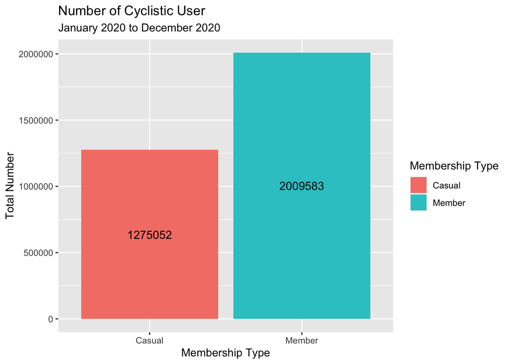

```r
#Number of user
cleanedBikeTrips_2020_v2 %>%
  group_by(Membership_Type) %>%
  summarise(Total_Number = n()) %>%
  arrange(Total_Number) %>%

  ggplot(aes(x = Membership_Type, y = Total_Number, fill = Membership_Type)) +
  geom_bar(stat = "identity") +
  stat_identity(geom = "text", colour = "black", size = 4, aes(label = Total_Number),
             position = position_stack(vjust=0.5)) +
  scale_fill_manual(name = "Membership Type", values = c(Casual = '#F48176', Member = '#30C7CC')) +
  labs(title = "Number of Cyclistic User" , x = "Membership Type", y = "Total Number",
       subtitle = "January 2020 to December 2020")
```

The bike types to membership types.

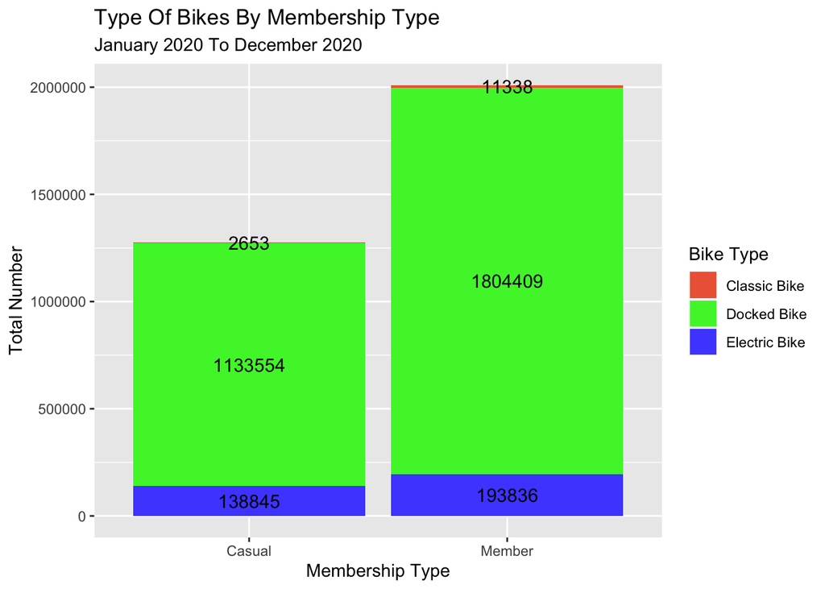

```r
#Bike Types to Membership Type

cleanedBikeTrips_2020_v2 %>%
  group_by(Bike_Type, Membership_Type) %>%
  summarise(Total_Number = n(), .groups = 'drop') %>%
  arrange(Total_Number) %>%

  ggplot(aes(x = Membership_Type , y = Total_Number, fill = Bike_Type)) +
  geom_bar (stat="identity")+
  stat_identity(geom = "text", colour = "black", size = 4, aes(label = Total_Number),
                position = position_stack(vjust=0.5)) +
  scale_fill_manual(name = "Bike Type",
                    labels = c("Classic Bike", "Docked Bike", "Electric Bike"),
                    values = c("#ed6645", "#48f235", "#4f52ff")) +
  labs(title = "Type Of Bikes By Membership Type", x = "Membership Type", y = "Total Number",
       subtitle = "January 2020 To December 2020")
```

Mean average of membership type to ride duration

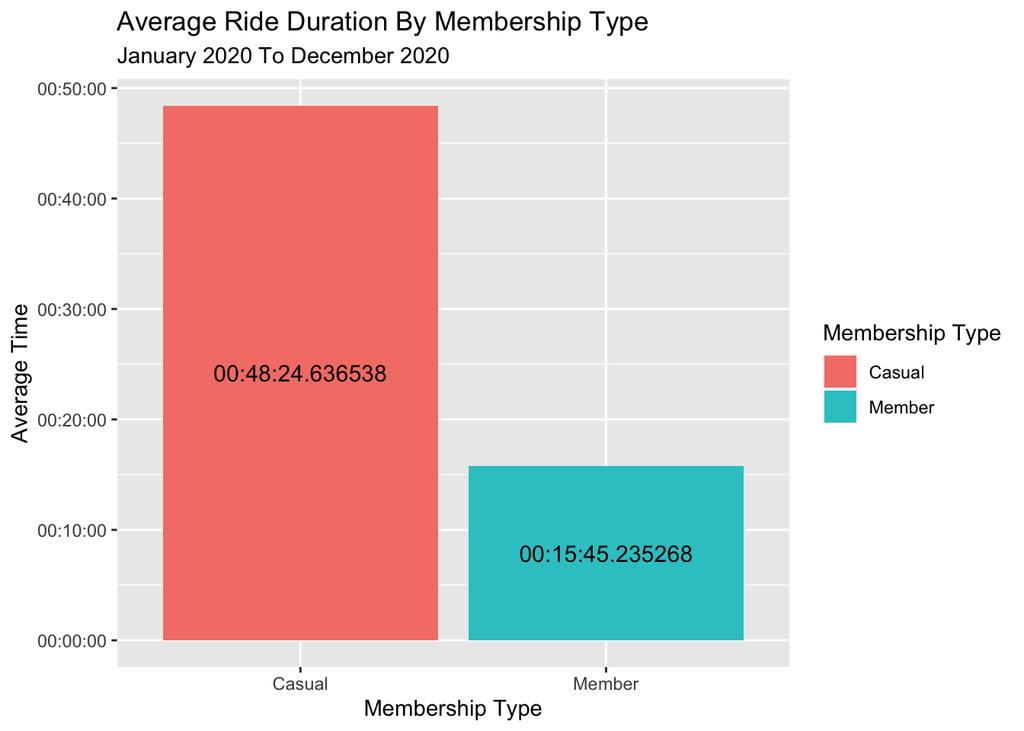

```r
#Mean average of membership type to ride duration

cleanedBikeTrips_2020_v2 %>%
  mutate(Average_Times = mean(Ride_Duration)) %>%
  group_by(Membership_Type, Average_Times) %>%
  summarise(.groups = 'drop', Average_Times = mean(Ride_Duration)) %>%
  arrange(Membership_Type, Average_Times) %>% mutate (Average_Time= hms(Average_Times)) %>%

  ggplot(aes(x = Membership_Type , y = Average_Time, fill = Membership_Type)) +
  geom_bar (stat="identity")+
  stat_identity(geom = "text", colour = "black", size = 4, aes(label = Average_Time),
                position = position_stack(vjust=0.5)) +

  scale_fill_manual(name = "Membership Type",
                    values = c(Casual = '#F48176', Member = '#30C7CC')) +
  labs(title = "Average Ride Duration By Membership Type", x = "Membership Type",
       y = "Average Time",
       subtitle = "January 2020 To December 2020")
```

Mean average of ride duration to membership type and day of ride

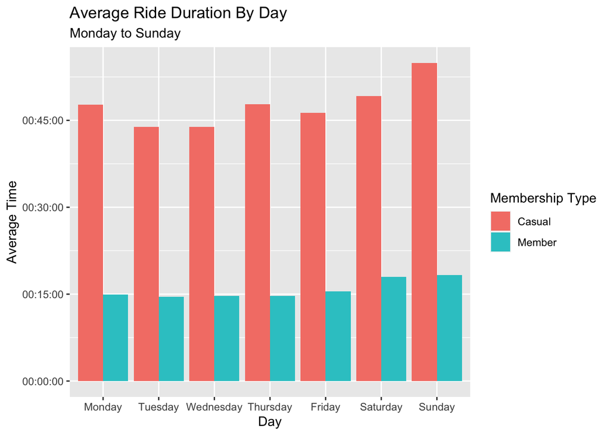

```r
cleanedBikeTrips_2020_v2 %>% mutate(Day = Day_Of_Week) %>%
  group_by(Membership_Type, Day) %>%
  summarise(.groups = 'drop', average_duration = mean(Ride_Duration)) %>%
  arrange(Membership_Type, Day) %>% mutate(Average_Time = hms(average_duration)) %>%

  ggplot(aes(x = Day, y = Average_Time, fill = Membership_Type)) +
  geom_col(position = 'dodge') +
  scale_fill_manual(name = "Membership Type",
                    values = c(Casual = '#F48176', Member = '#30C7CC')) +
  labs(title = "Average Ride Duration By Day", x = "Day", y = "Average Time",
       subtitle = "Monday to Sunday")
```

Mean average of ride duration to membership type and months

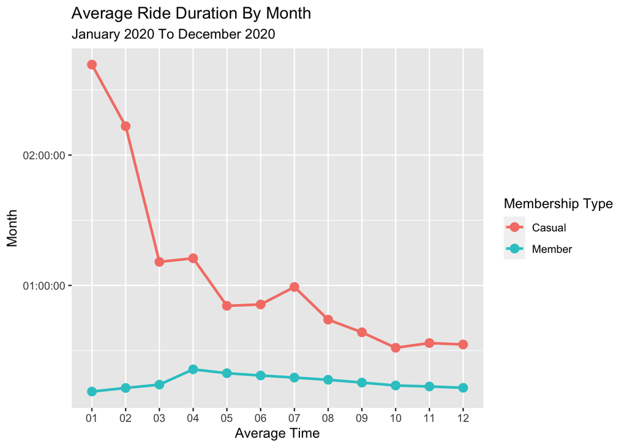

```r
cleanedBikeTrips_2020_v2 %>% mutate(Month = Month) %>%
  group_by(Membership_Type, Month) %>%
  summarise(.groups = 'drop', average_duration = mean(Ride_Duration)) %>%
  arrange(Membership_Type, Month) %>% mutate(Average_Time = hms(average_duration)) %>%

  ggplot(aes(x = Month, y = Average_Time, group = Membership_Type, colour = Membership_Type)) +
  geom_line(size = 1) + geom_point(size = 3) +
  scale_colour_manual(name = "Membership Type",
                    values = c(Casual = '#F48176', Member = '#30C7CC')) +
  labs(title = "Average Ride Duration By Month", x = "Average Time", y = "Month",
       subtitle = "January 2020 To December 2020")
```

### Act - Conclusion and Recommendation

From the analysis, it is clear that casual membership has a higher average of riding time compare to the member membership. The number is increasing during the weekend, which suggesting many casual member might be a tourists. The member membership usage pattern is almost flat and constant, which suggesting man of member membership are the resident.